# State MSM Profile: **Illinois**

### Background & Methods

In 2015-2016, researchers at Emory University partnered with colleagues at the Centers for Disease Control and Prevention (CDC) to develop methods to estimate the number of men who have sex with men (MSM) residing in each county in the United States. Using population and housing data from the [American Community Survey](https://www.census.gov/programs-surveys/acs/) and estimates from two peer-reviewed publications ([Oster et al., 2015](http://www.ncbi.nlm.nih.gov/pubmed/26115985) & [Purcell et al., 2012](http://www.ncbi.nlm.nih.gov/pubmed/23049658)), they derived an indirect estimate of MSM population sizes that took into account both the urbanicity of the county as well as its density of households with a male householder and a male same-sex partner.

The full methodology is published in the *Journal of Medical Internet Research - Public Health and Surveillance*:

> [Grey JA, Bernstein KT, Sullivan PS, Purcell DW, Chesson HW, Gift TL, Rosenberg ES. Estimating the population sizes of men who have sex with men in US states and counties using data from the American Community Survey. JMIR Public Health Surveill 2016;2(1):e14. DOI: 10.2196/publichealth.5365](http://publichealth.jmir.org/2016/1/e14/)

### Overview of MSM in Illinois

An estimated **199,486** men who have sex with men (MSM) resided in Illinois in 2013, representing 4.4% of the 4,503,084 MSM in the United States. Of the 4,728,089 adult men of Illinois, 4.2% had had sex with another man in the past 5 years, which was greater than the overall percentage of adult men in the United States who were MSM (3.9%).

Most MSM in Illinois resided in central counties of large metropolitan areas (63.1%). Including both central and fringe counties, 86.8% resided in a large metropolitan area.

##### **Percentage of MSM by urbanicity, United States and Illinois, 2013**

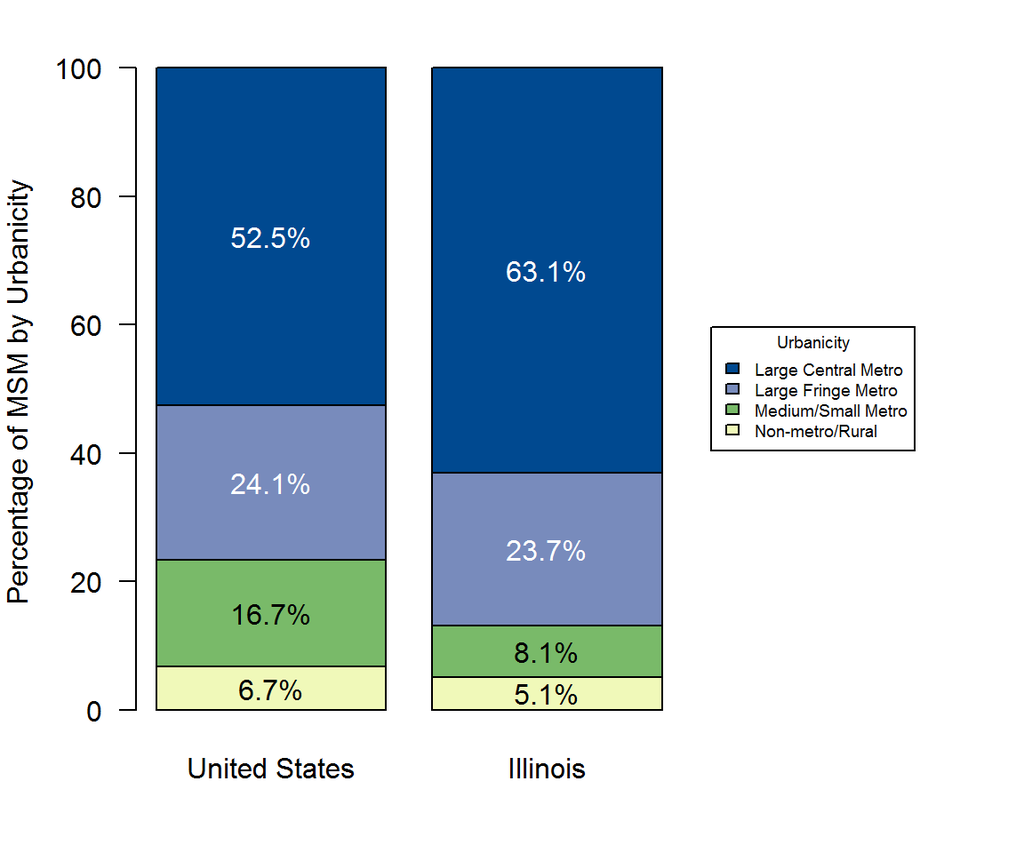

### MSM in Illinois Counties

Among counties or county-equivalent areas in Illinois, Cook County had the largest population of MSM at 125,923, representing 63.1% of all MSM in the state. Cook County also had the highest percentage of MSM among adult men in Illinois at 6.6%. This was greater than the percentage for Illinois as a whole, which was 4.2% of adult men.

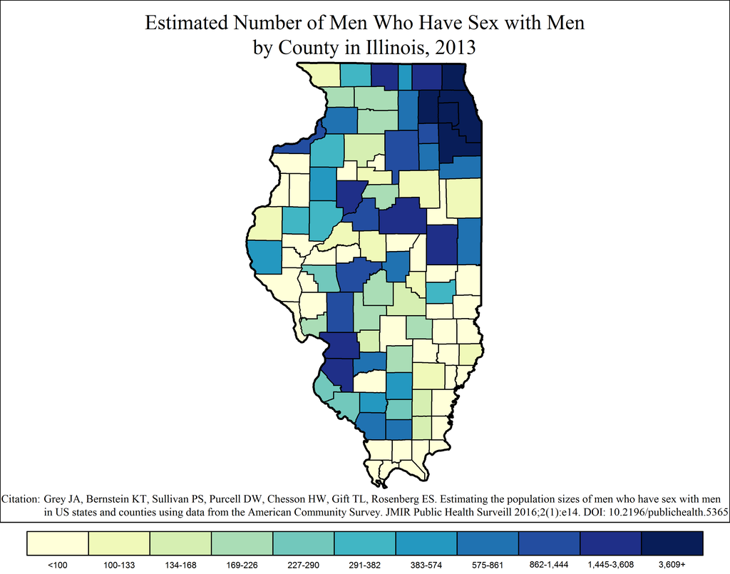

Note: Range cutpoints for the map are based on the distribution of MSM among all counties in the United States.

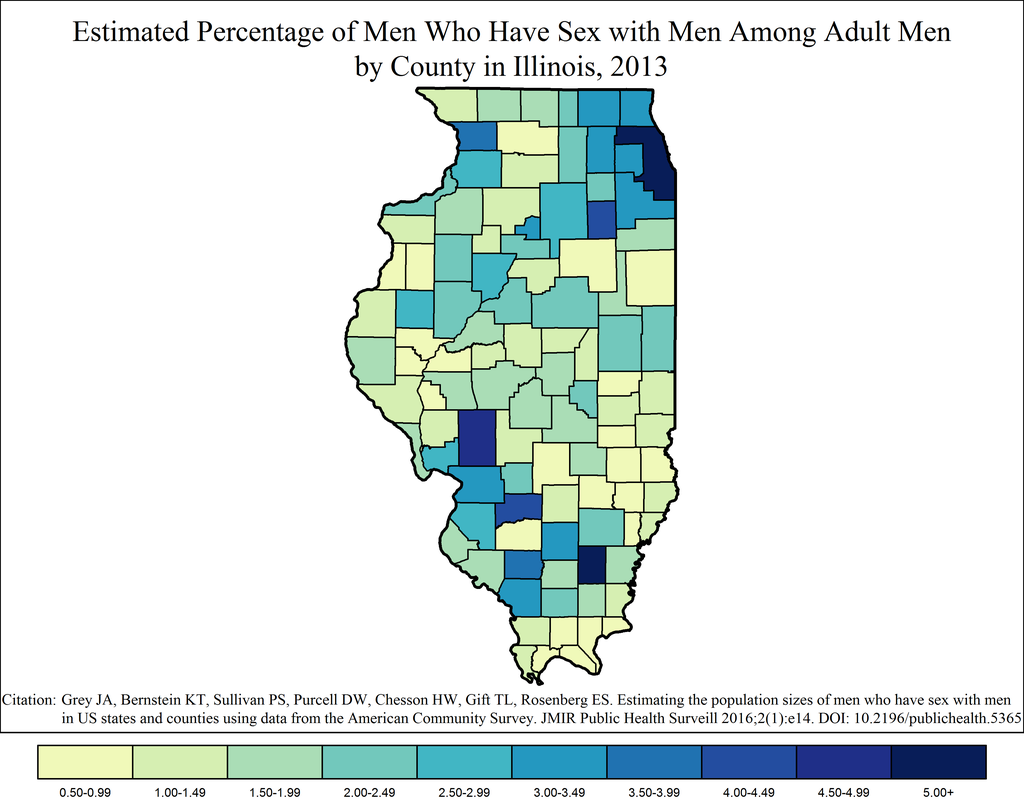

### MSM in Illinois Metropolitan Statistical Areas

#### Chicago-Naperville-Elgin Metropolitan Statistical Area

The Chicago-Naperville-Elgin MSA overlaps three states: Illinois, Indiana and Wisconsin. The Illinois portion of the MSA had the largest metropolitan population of MSM in Illinois at 165,226, or 82.8% of all MSM in the state and 94.4% of the 175,118 MSM in the MSA. Of the 3,128,720 adult men in the Illinois part of Chicago-Naperville-Elgin, an estimated 5.3% were MSM. This was greater than the percentage of MSM among adult men in the MSA as a whole, which was 5.1% of adult men (175,118 out of 3,443,489).

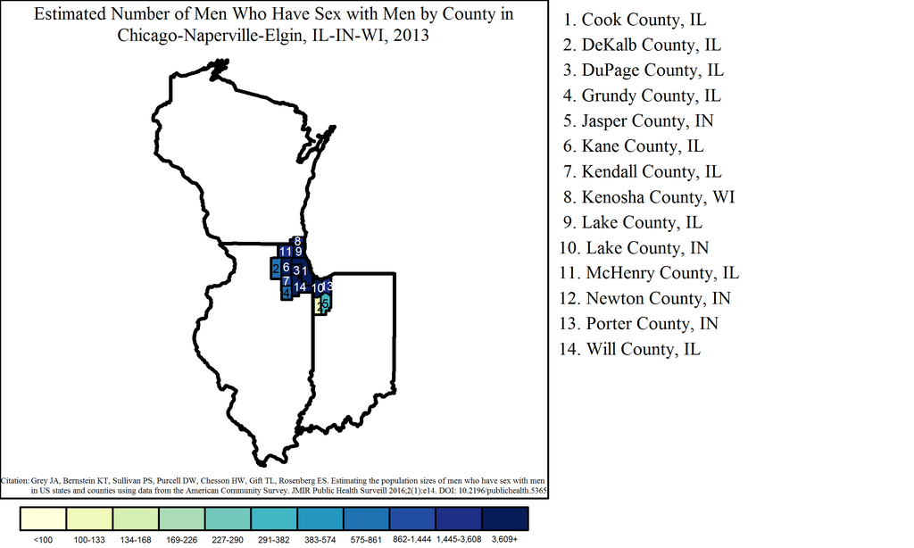

Note: Range cutpoints for the map are based on the distribution of MSM among all counties in the United States.

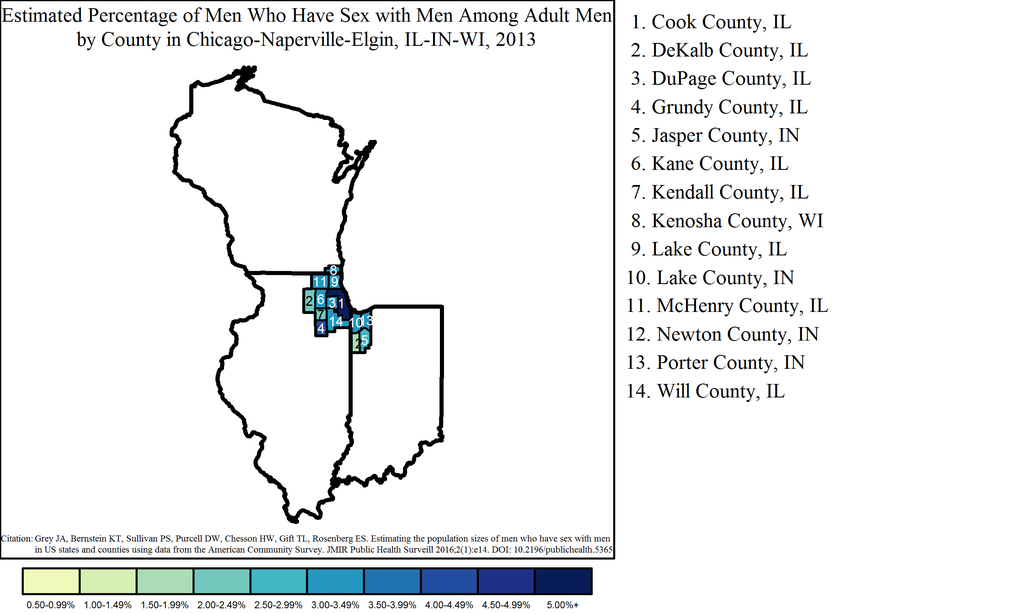

#### St. Louis Metropolitan Statistical Area

The St. Louis MSA overlaps two states: Illinois and Missouri. The Illinois portion of the MSA had 7,985 MSM, or 4.0% of all MSM in the state and 20.9% of the 38,221 MSM in the MSA. Of 257,783 adult men in the Illinois part of St. Louis, 3.1% were MSM. This was less than the overall percentage of MSM among adult men in the MSA, which was 3.8% of adult men (38,221 out of 1,015,361).

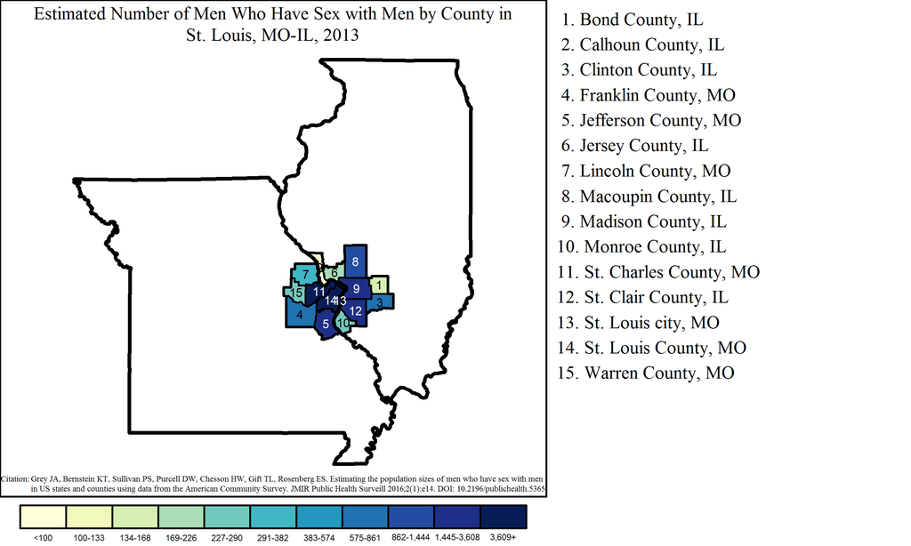

Note: Range cutpoints for the map are based on the distribution of MSM among all counties in the United States.

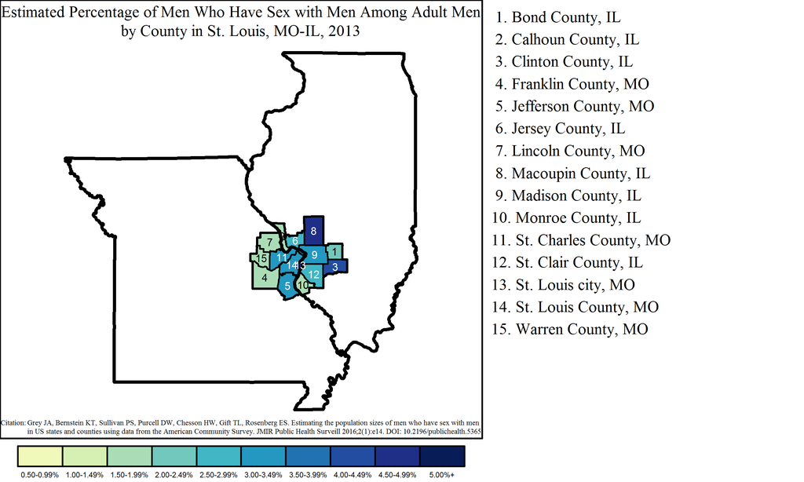

#### Peoria Metropolitan Statistical Area

The Peoria MSA had a population of 3,231 MSM, or 1.6% of all MSM in Illinois. Of the 139,680 adult men in Peoria, an estimated 2.3% were MSM.

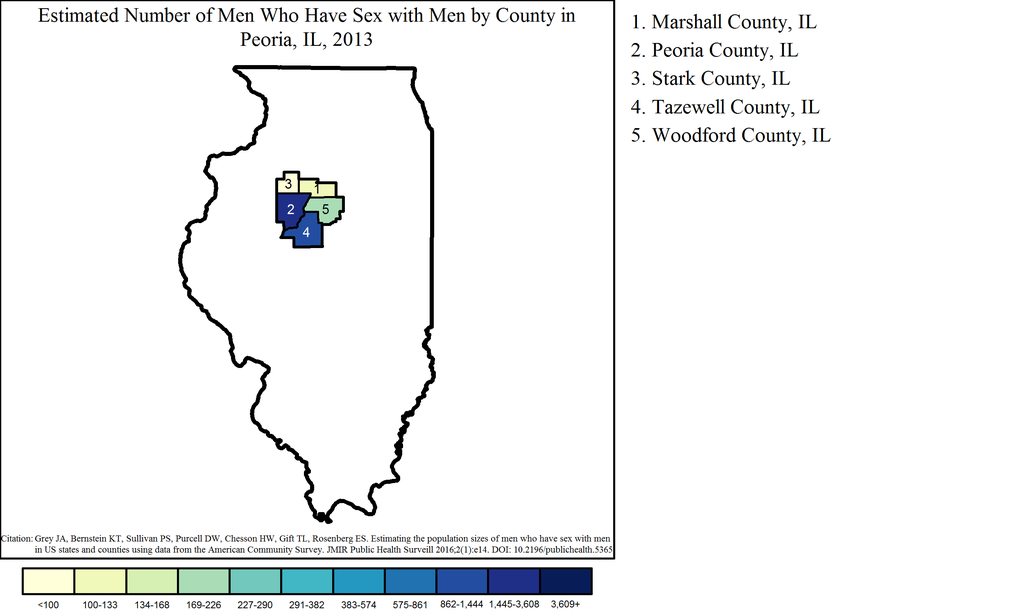

Note: Range cutpoints for the map are based on the distribution of MSM among all counties in the United States.

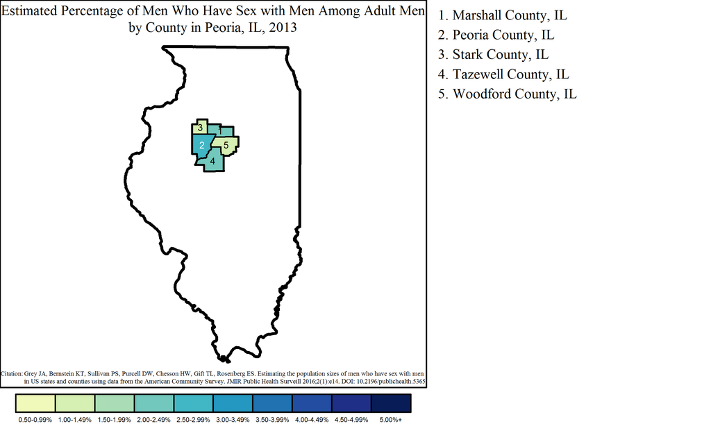

#### Rockford Metropolitan Statistical Area

The Rockford MSA had a population of 2,388 MSM, or 1.2% of all MSM in Illinois. Of the 125,835 adult men in Rockford, an estimated 1.9% were MSM.

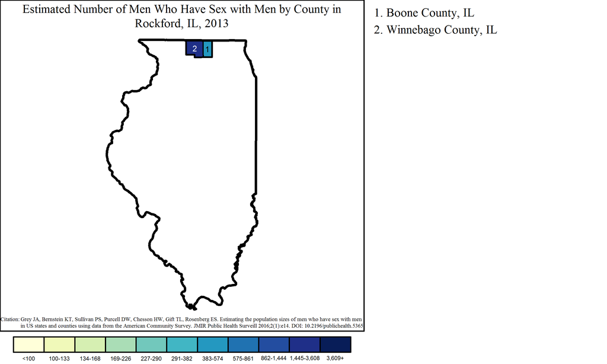

Note: Range cutpoints for the map are based on the distribution of MSM among all counties in the United States.

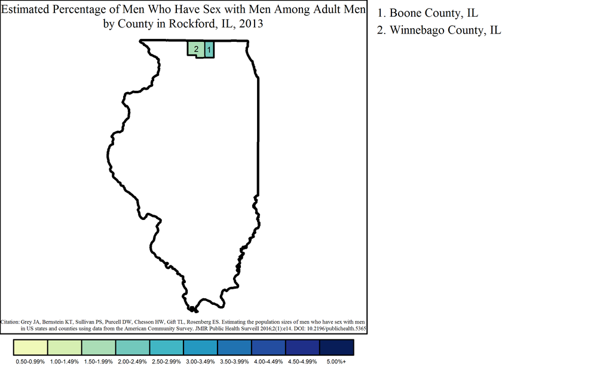

#### Champaign-Urbana Metropolitan Statistical Area

The Champaign-Urbana MSA had a population of 2,079 MSM, or 1.0% of all MSM in Illinois. Of the 92,658 adult men in Champaign-Urbana, an estimated 2.2% were MSM.

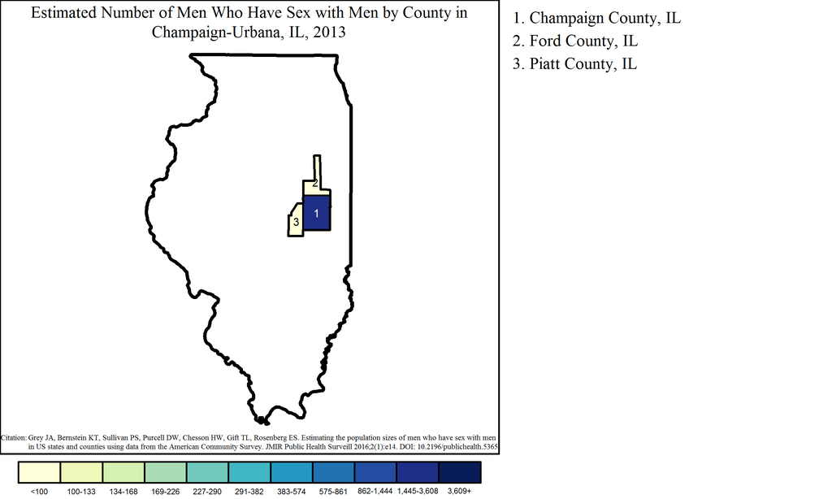

Note: Range cutpoints for the map are based on the distribution of MSM among all counties in the United States.

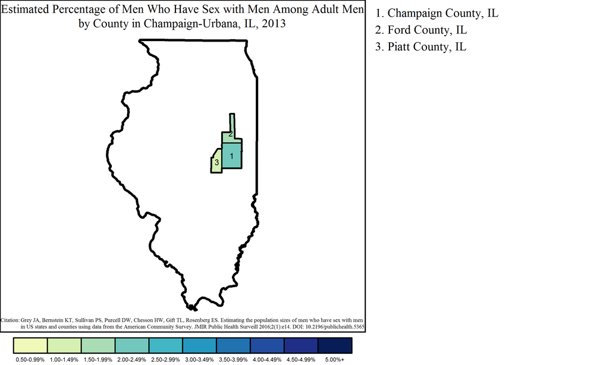

#### Davenport-Moline-Rock Island Metropolitan Statistical Area

The Davenport-Moline-Rock Island MSA overlaps two states: Illinois and Iowa. The Illinois portion of the MSA had 1,705 MSM, or 0.9% of all MSM in the state and 58.0% of the 2,939 MSM in the MSA. Of 80,411 adult men in the Illinois part of Davenport-Moline-Rock Island, 2.1% were MSM. This was equal to the overall percentage of MSM among adult men in the MSA, which was 2.1% of adult men (2,939 out of 141,506).

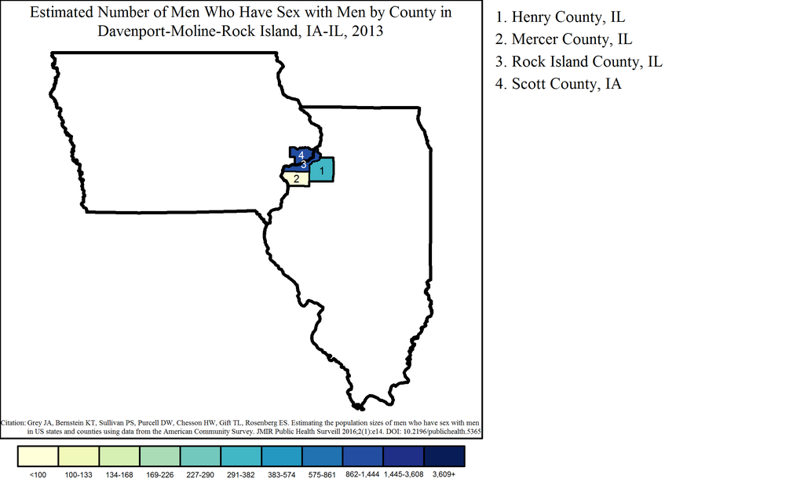

Note: Range cutpoints for the map are based on the distribution of MSM among all counties in the United States.

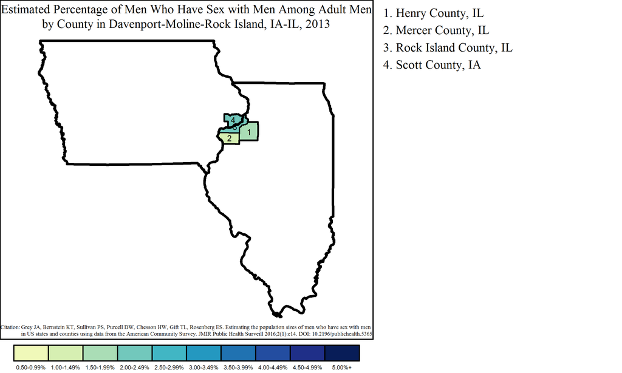

#### Bloomington Metropolitan Statistical Area

The Bloomington MSA had a population of 1,610 MSM, or 0.8% of all MSM in Illinois. Of the 69,954 adult men in Bloomington, an estimated 2.3% were MSM.

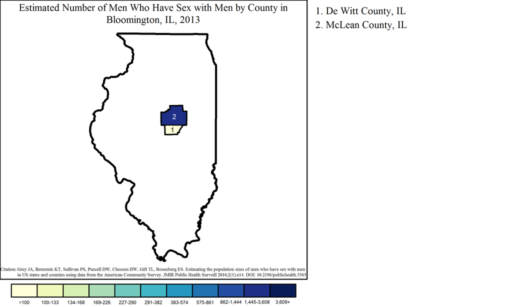

Note: Range cutpoints for the map are based on the distribution of MSM among all counties in the United States.

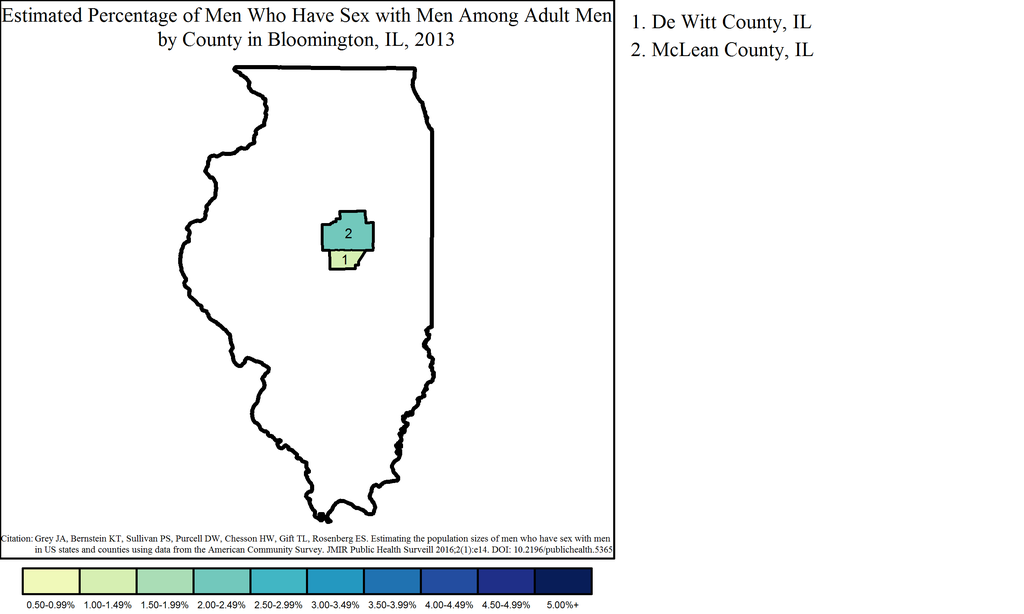

#### Springfield Metropolitan Statistical Area

The Springfield MSA had a population of 1,425 MSM, or 0.7% of all MSM in Illinois. Of the 76,122 adult men in Springfield, an estimated 1.9% were MSM.

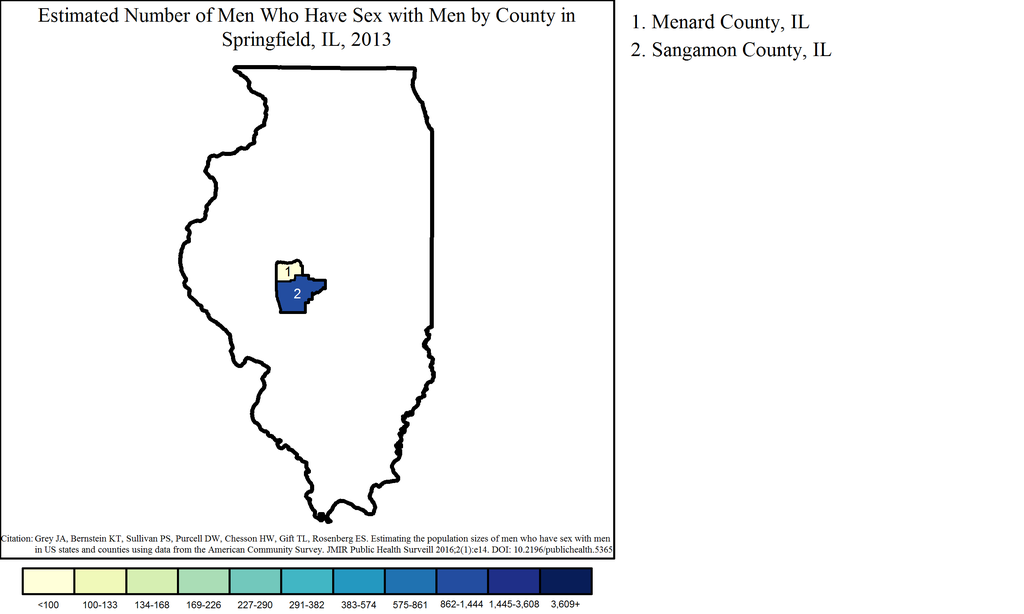

Note: Range cutpoints for the map are based on the distribution of MSM among all counties in the United States.

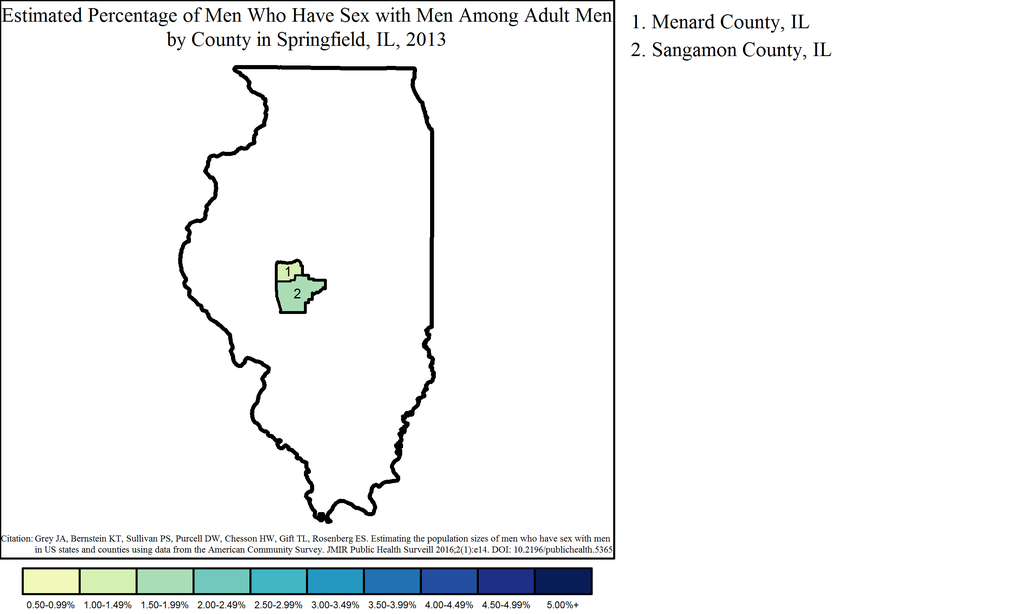

#### Carbondale-Marion Metropolitan Statistical Area

The Carbondale-Marion MSA had a population of 1,415 MSM, or 0.7% of all MSM in Illinois. Of the 50,321 adult men in Carbondale-Marion, an estimated 2.8% were MSM.

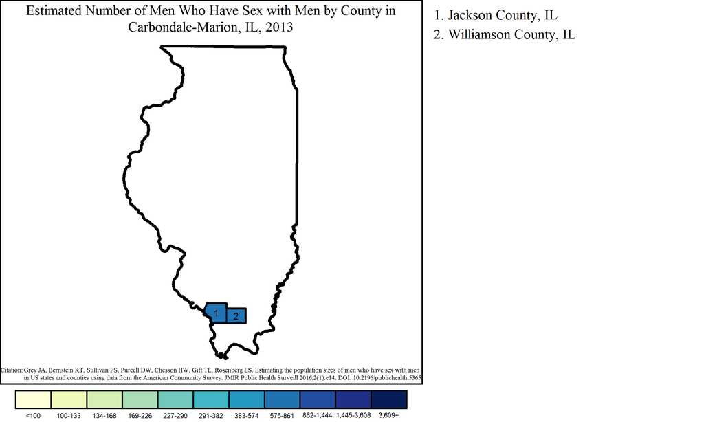

Note: Range cutpoints for the map are based on the distribution of MSM among all counties in the United States.

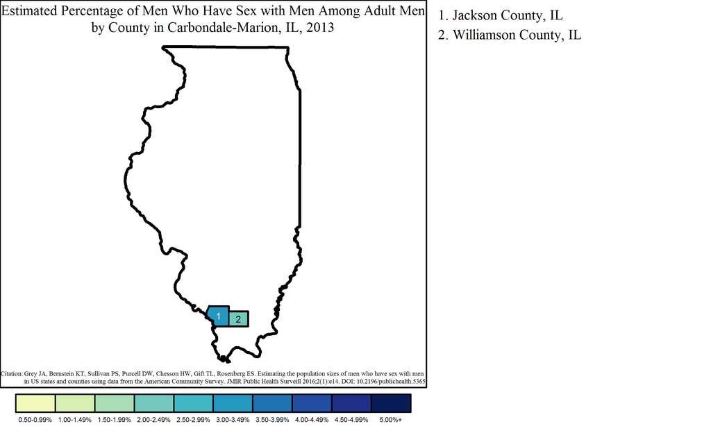

#### Kankakee Metropolitan Statistical Area

The Kankakee MSA had a population of 811 MSM, or 0.4% of all MSM in Illinois. Of the 40,907 adult men in Kankakee, an estimated 2.0% were MSM.

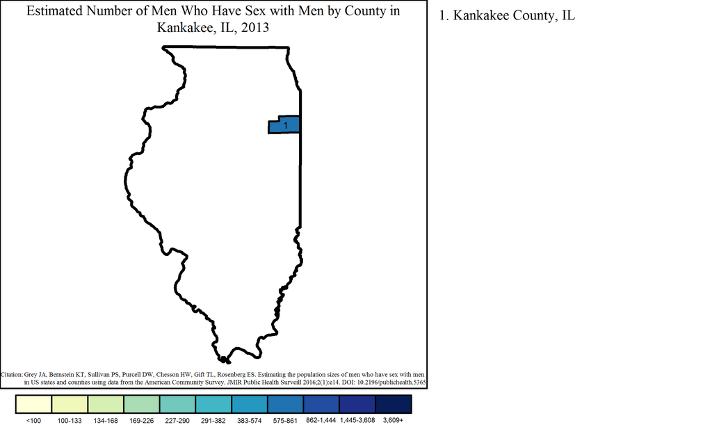

Note: Range cutpoints for the map are based on the distribution of MSM among all counties in the United States.

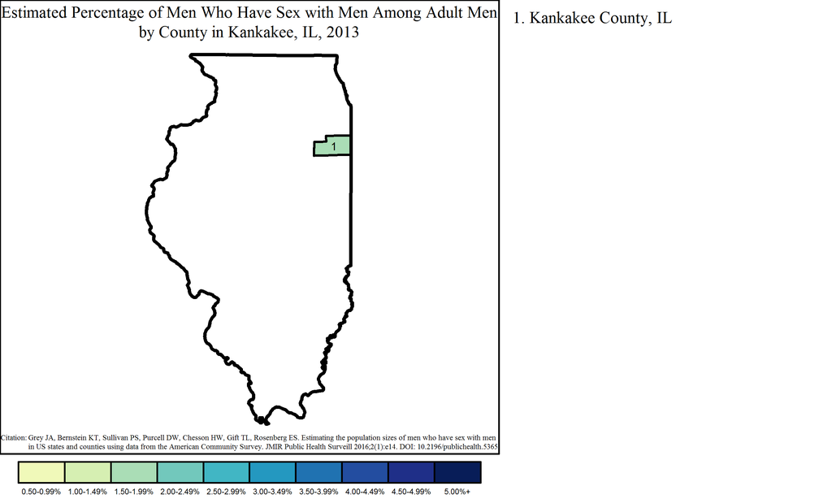

#### Decatur Metropolitan Statistical Area

The Decatur MSA had a population of 766 MSM, or 0.4% of all MSM in Illinois. Of the 40,214 adult men in Decatur, an estimated 1.9% were MSM.

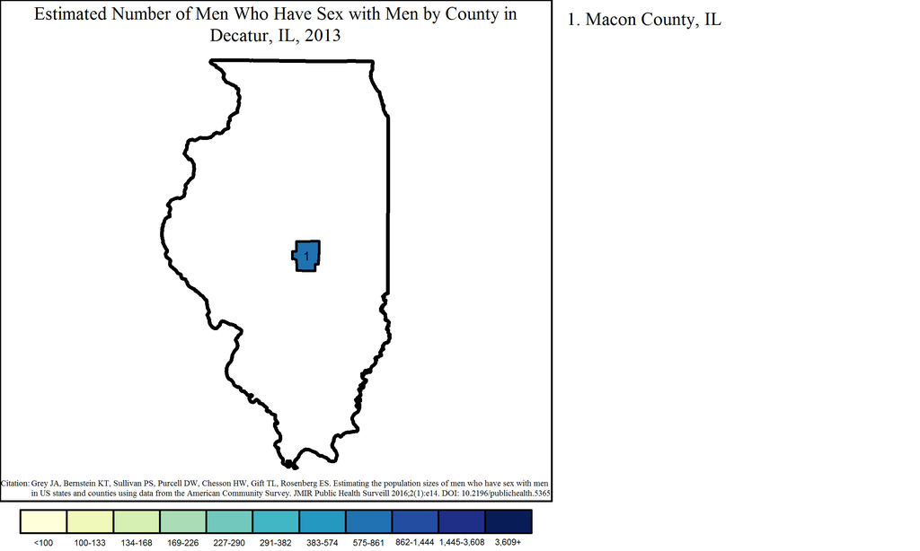

Note: Range cutpoints for the map are based on the distribution of MSM among all counties in the United States.

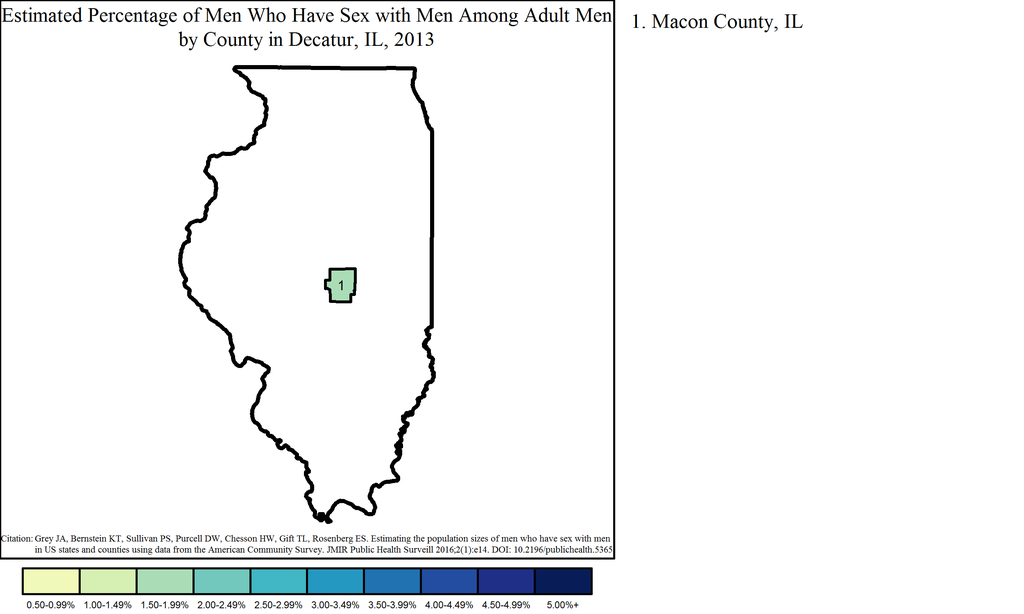

#### Danville Metropolitan Statistical Area

The Danville MSA had a population of 644 MSM, or 0.3% of all MSM in Illinois. Of the 30,186 adult men in Danville, an estimated 2.1% were MSM.

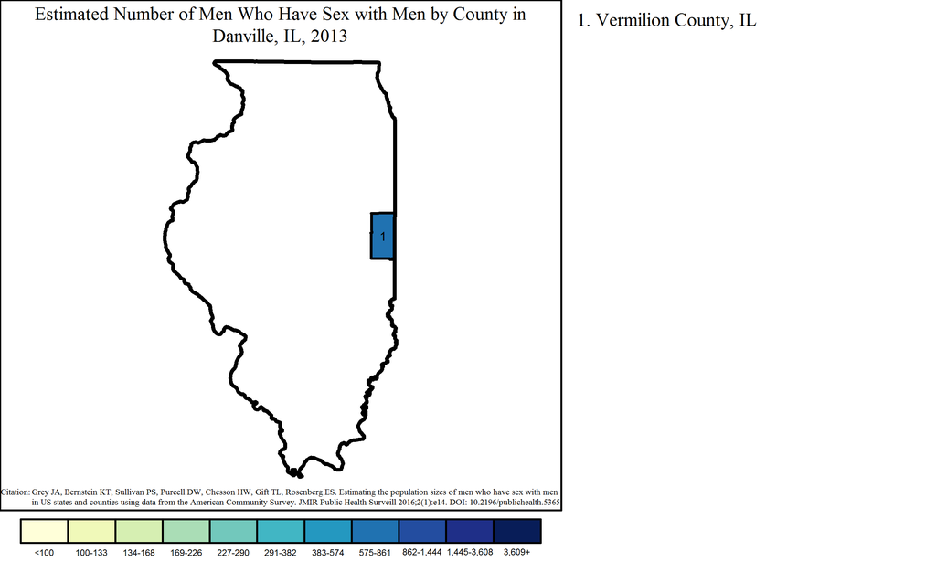

Note: Range cutpoints for the map are based on the distribution of MSM among all counties in the United States.

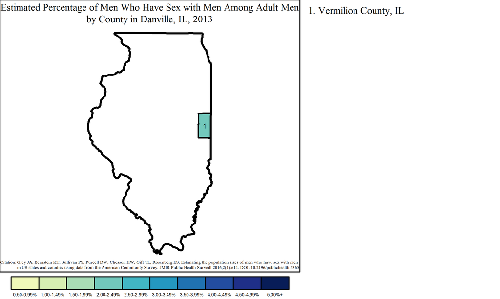

#### Cape Girardeau Metropolitan Statistical Area

The Cape Girardeau MSA overlaps two states: Illinois and Missouri. The Illinois portion of the MSA had 34 MSM, or 0.0% of all MSM in the state and 4.9% of the 692 MSM in the MSA. Of 3,099 adult men in the Illinois part of Cape Girardeau, 1.1% were MSM. This was less than the overall percentage of MSM among adult men in the MSA, which was 1.9% of adult men (692 out of 36,166).

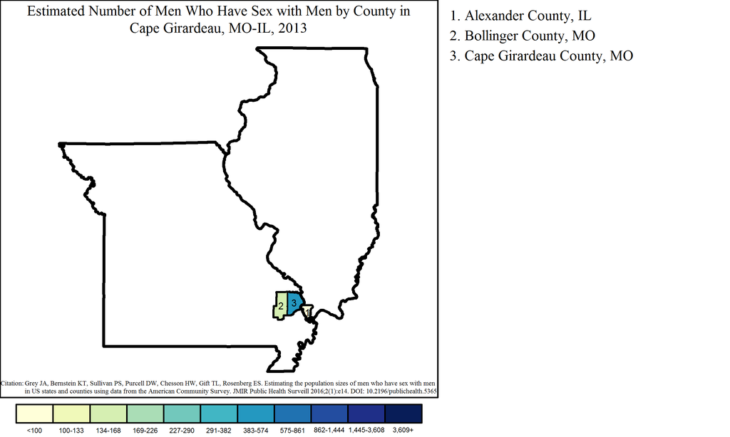

Note: Range cutpoints for the map are based on the distribution of MSM among all counties in the United States.

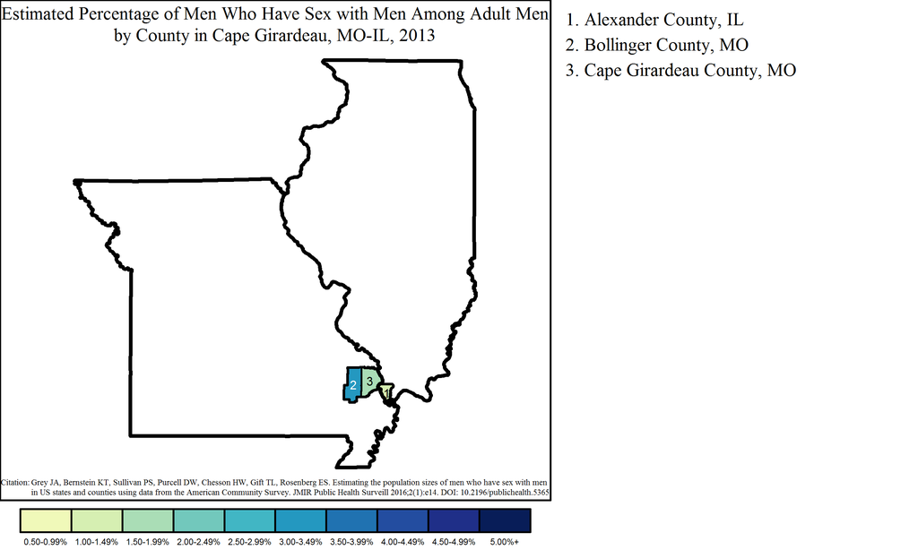